# Trp53cor1 KO vs WT (rmdup_lung)

This file shows the wt-v-ko comparison for Trp53cor1.

Cuff overview:

```
## CuffSet instance with:
##   2 samples
##   26754 genes
##   77524 isoforms
##   0 TSS
##   23066 CDS
##   0 promoters
##   0 splicing
##   19954 relCDS
```

# QC

## Dispersion

Dispersion plot for genes in cuff: (Overdispersion can lead to innacurate quants)

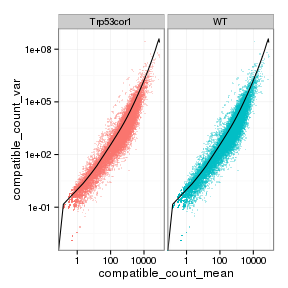

## Cross-replicate variability (fpkmSCVplot)

Differences in CV 2 can result in lower numbers of differentially expressed genes due to a higher degree of variability between replicate fpkm estimates.

Genes:

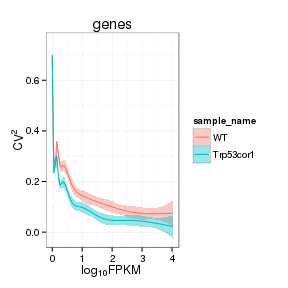

Isoforms:

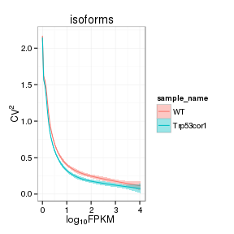

## MvA plot

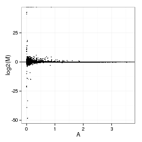

### MvA plot counts

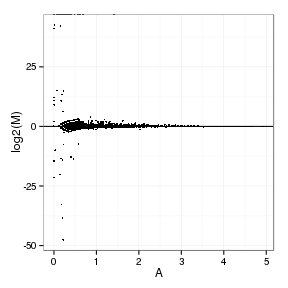

## Scatterplot matrix

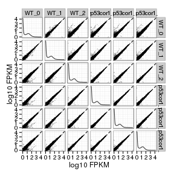

## Distributions

### Boxplots

Boxplot (genes)

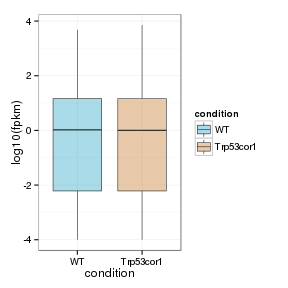

Boxplot (genes, replicates)

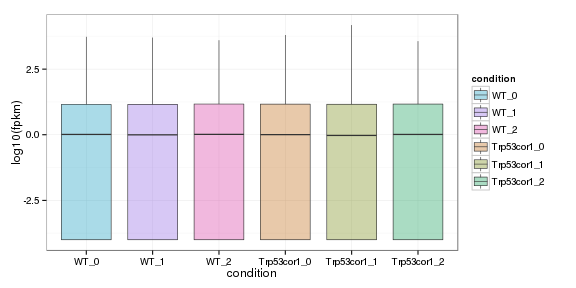

Boxplot (isoforms)

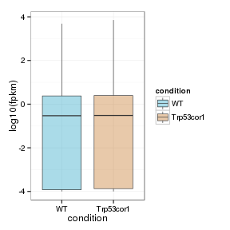

Boxplot (isoforms, replicates)

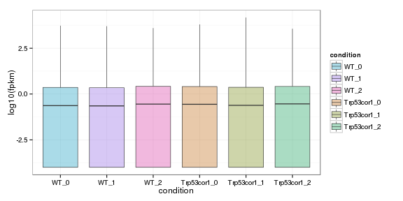

### Density

Density (genes)

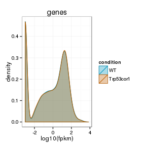

Density (genes, replicates)

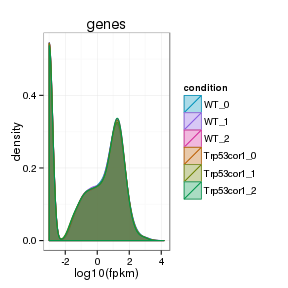

## Clustering

### Replicate Clusters

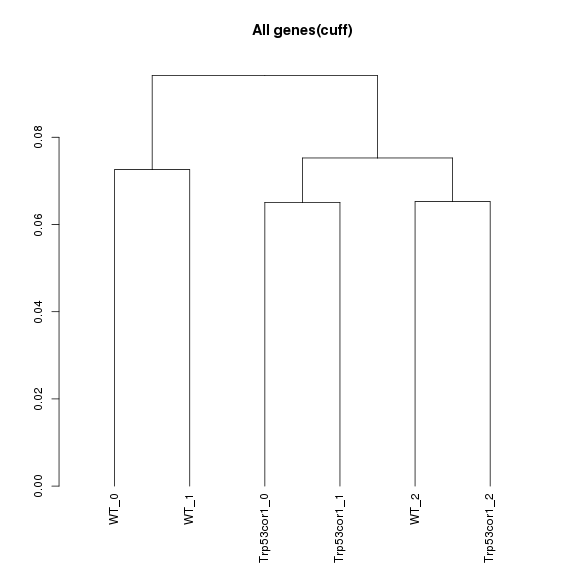

### PCA (genes)

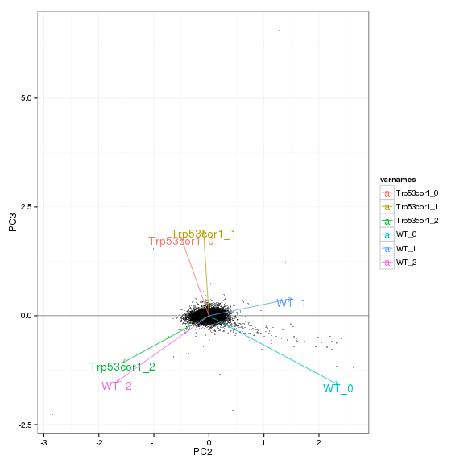

### MDS (genes)

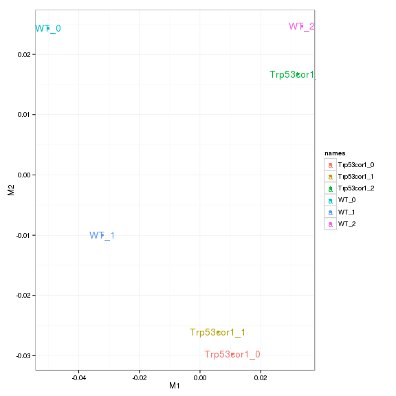

# KO assessment

## Endogenous lncRNA expression

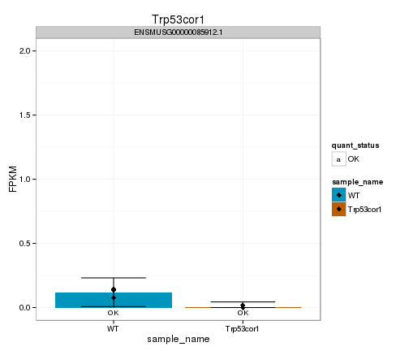

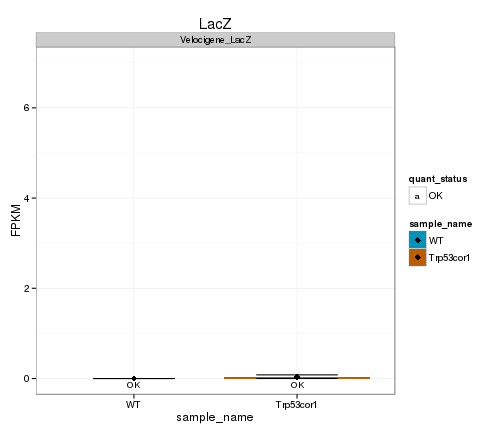

## Digital Genotyping (LacZ vs Endogenous lncRNA and Sex)

Eif2s3y is a y-expressed gene, Xist is an x-expressed gene Expression plot (endogenous linc, lacZ, Y-expressed gene):

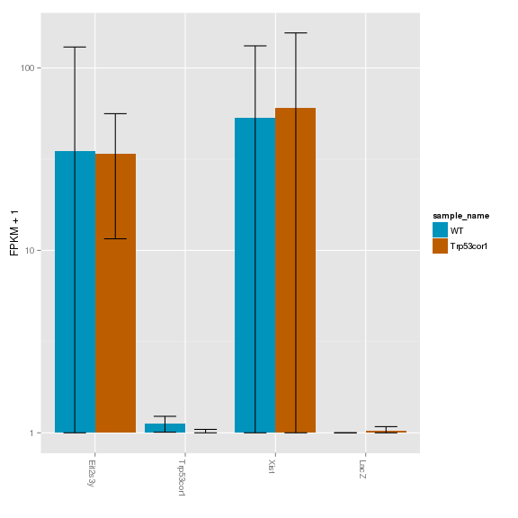

Expression heatmap:

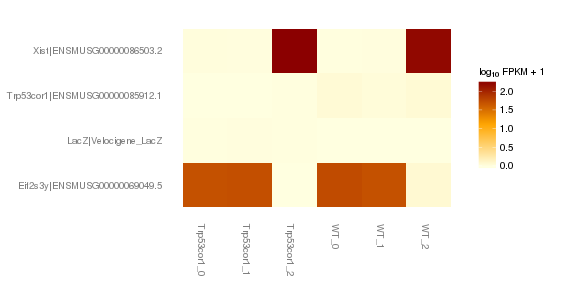

### Track visualization

[output not shown]

# Differential Analysis

## Differential Genes

There are 99 significantly differentially expressed genes. They are:

|  | geneAnnot$gene_short_name |
| --- | --- |
| 1 | Mybpc3 |
| 2 | Cd36 |
| 3 | Ctse |
| 4 | Corin |
| 5 | Hspb7 |
| 6 | Casq1 |
| 7 | Tcap |
| 8 | Cacna2d2 |
| 9 | Aldh1a2 |
| 10 | Myl2 |
| 11 | Eef1a2 |
| 12 | Gpx3 |
| 13 | Myl7 |
| 14 | Pgam2 |
| 15 | Myh3 |
| 16 | Asb2 |
| 17 | Ryr2 |
| 18 | Cap2 |
| 19 | Ldb3 |
| 20 | Ppp1r1a |
| 21 | Fgf12 |
| 22 | Prkdc |
| 23 | Cdkn1a |
| 24 | Polh |
| 25 | Glo1 |
| 26 | Prss41 |
| 27 | Tpsab1 |
| 28 | Camk2a |
| 29 | Ankrd1 |
| 30 | Cox8b |

[output cut: 69 more lines]

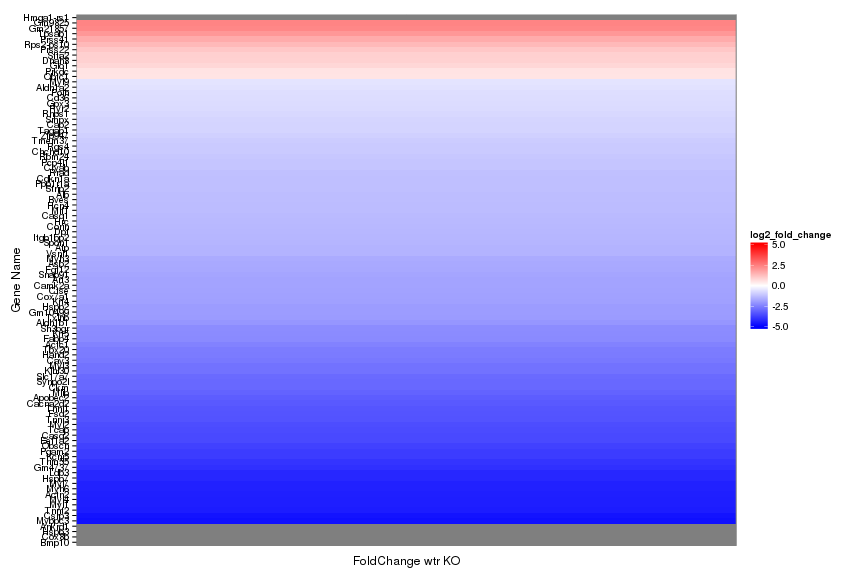

Expression heatmap of sigGenes

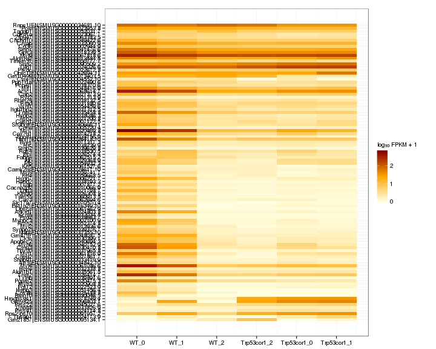

Foldchange heatmap of sigGenes

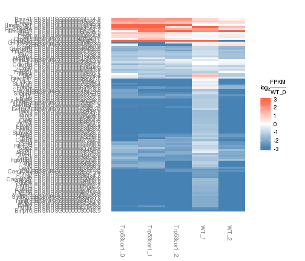

Now, look at genes that are detectably expressed (FPKM>0.5, yes I know it should be 1), and log2foldchange>2 in any direction: 117 genes

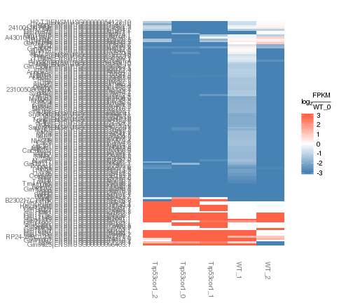

Now, those that are expressed, changing and called sig: 46 genes

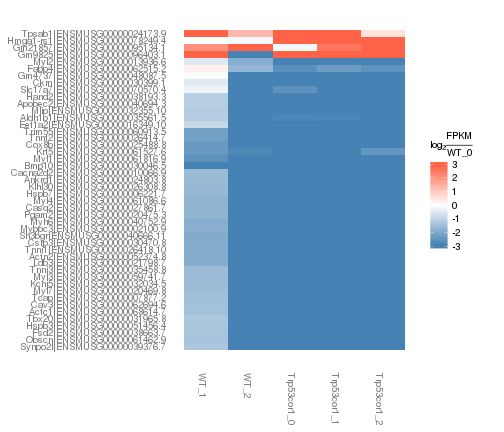

### Expression-level/significance relationship

Scatter plot of significant genes only:

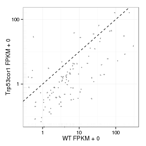

Volcano Plot

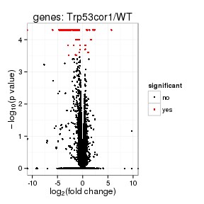

Volcano plot with significant genes only:

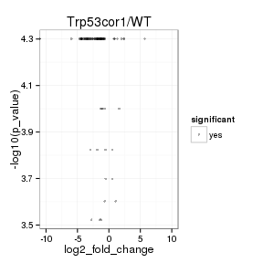

### Differential Isoforms between conditions

Per isoform difference between conditions:

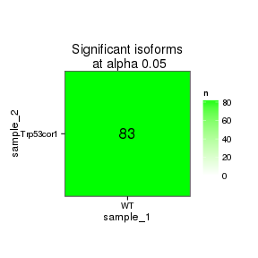

[output not shown]

These isoforms are:

[output not shown]

DE isoform heatmap

[output not shown]

Isoform foldchange heatmap by isoform:

[output not shown]

# Gene/Pathway Analysis

## GSEA

Enrichment and zscores are calculated based on expression in KO vs WT (fpkmKO/fpkmWT), so genes that are down regulated in KO are shown in blue, while upregulation is shown in red.

KO/WT Blue = down in KO Red = Up in KO

Biocarta enrichment:

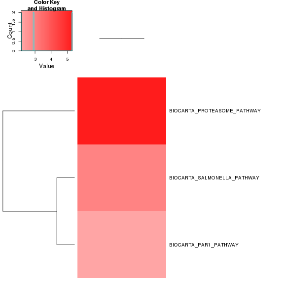

Biocarta zscore:

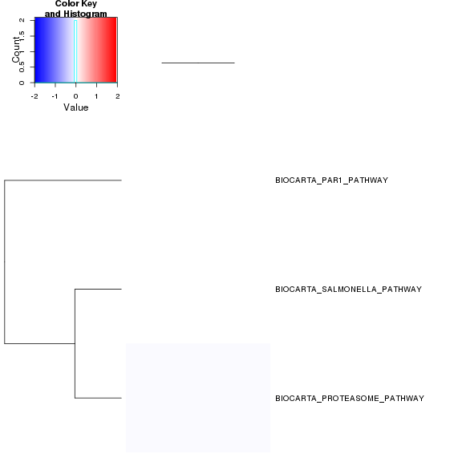

Reactome enrichment:

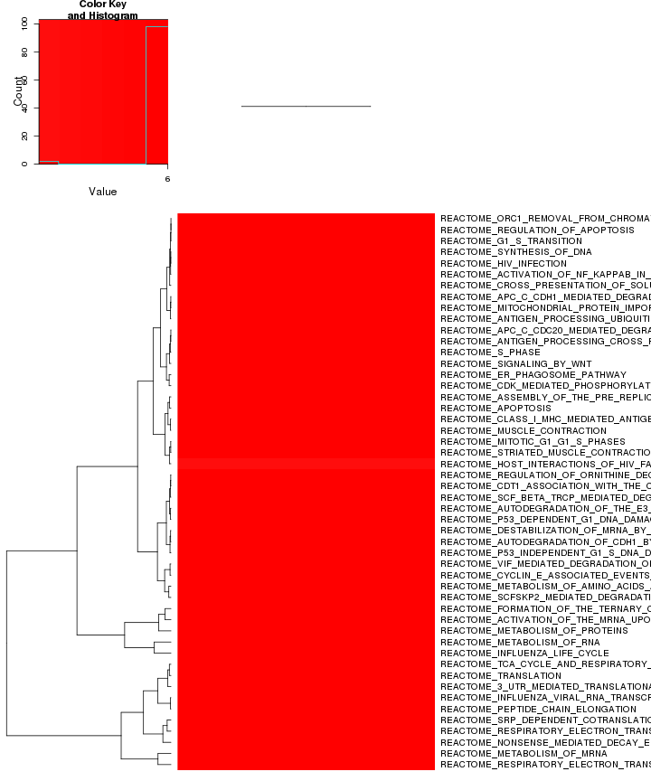

Reactome zscore:

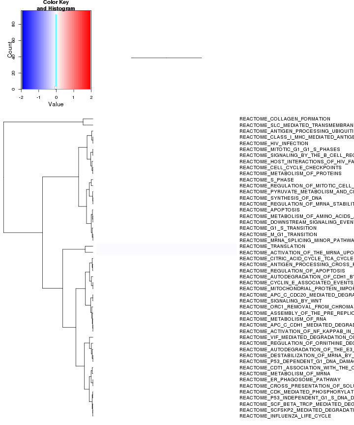

Kegg enrichment:

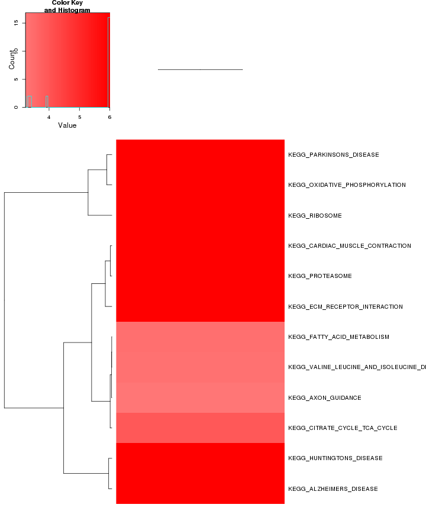

Kegg zscore:

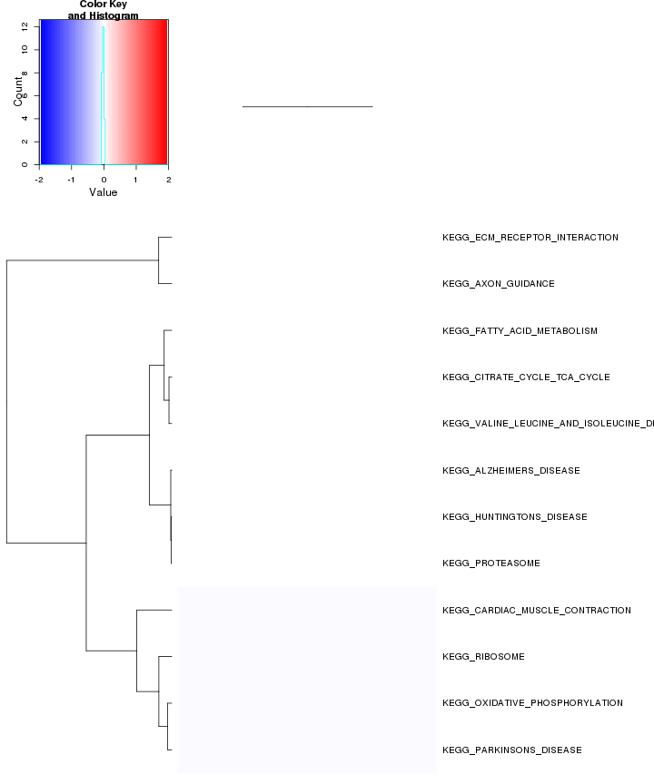

p53 enrichment:

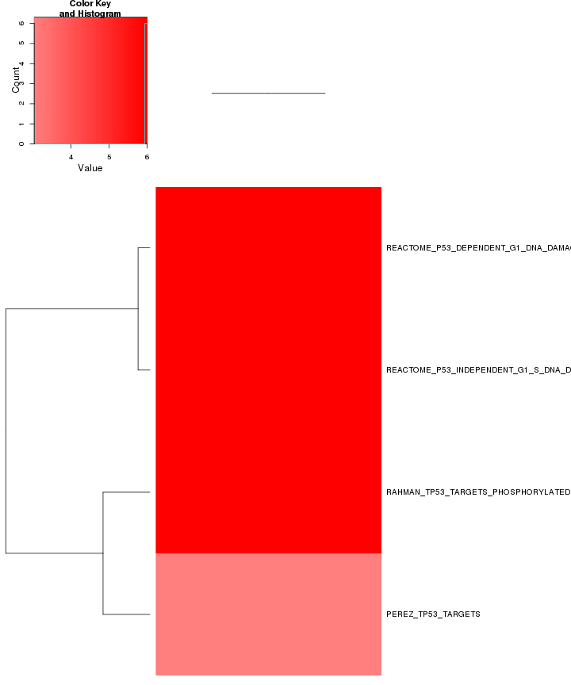

p53 zscore:

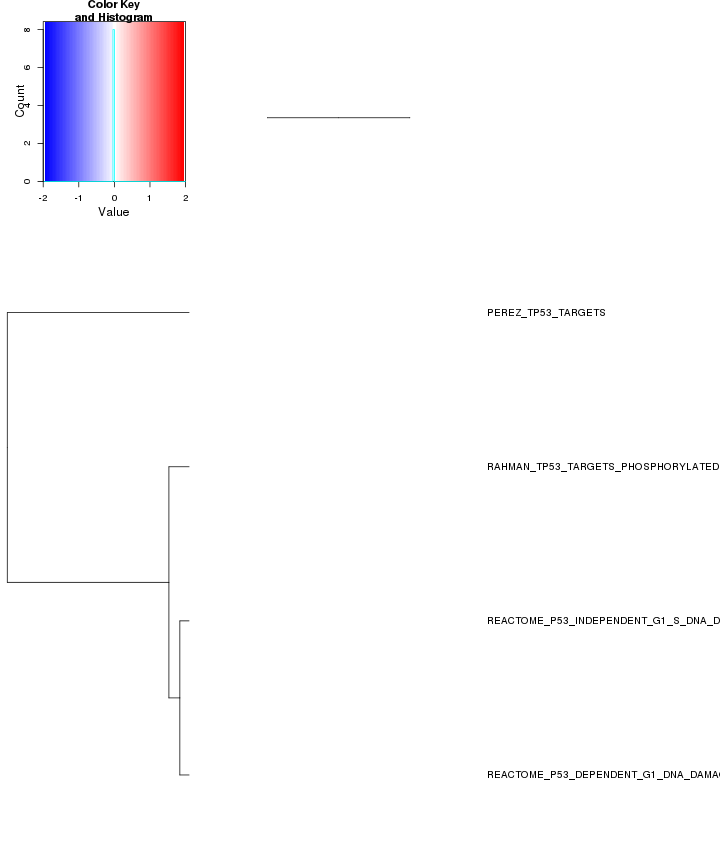

Oncogene enrichment:

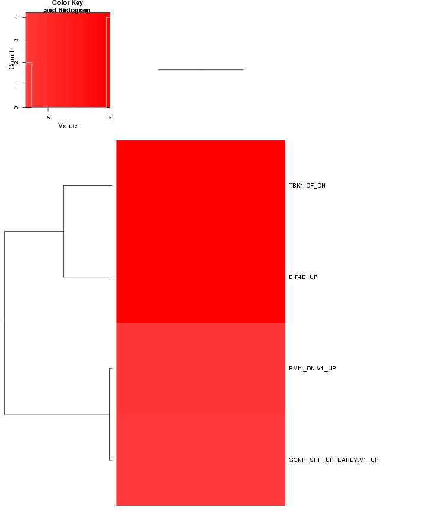

Oncogene zscore:

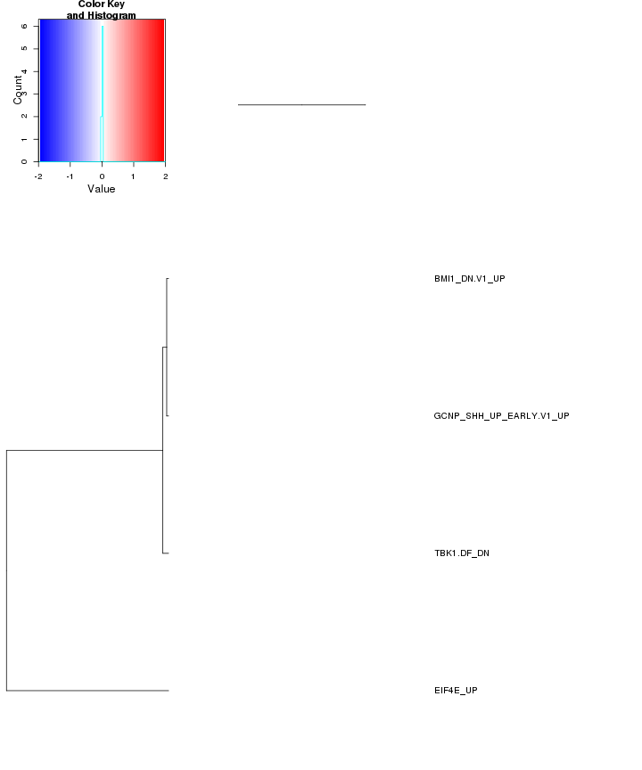

Jacks enrichment

```
## [1] "Not enough significant categories to print a heatmap!"
```

Jacks zscore

```
## [1] "Not enough significant categories to print a heatmap!"
```

All enrichment

There are 830 categories enriched (p<0.0001). They are:

[output not shown]

[figure not shown]

ALL zscore:

[output not shown]

[figure not shown]

## GO enrichment

Cluster profiler used to call enichments of significantly differentially regulated genes that map to Entrez IDs.

[output not shown]

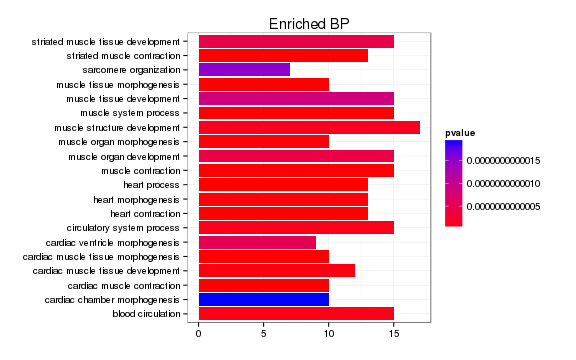

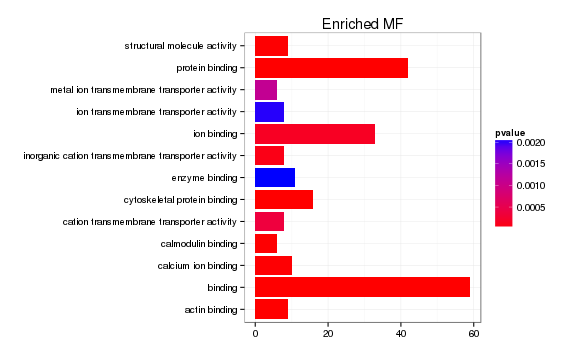

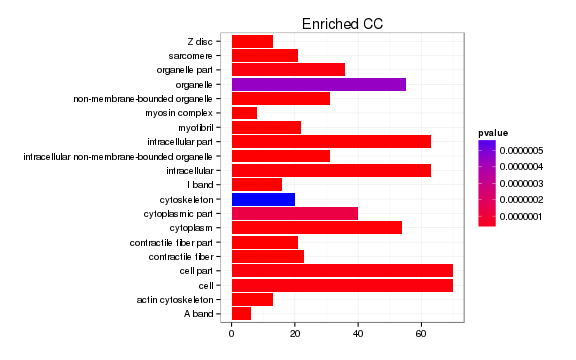

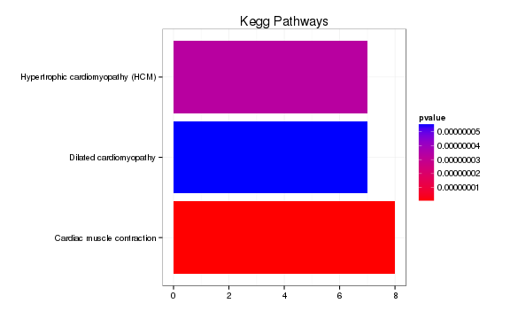

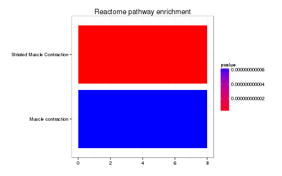

# Cis vs Trans (locally)

log2 Foldchange and test statistic are calculated with the ratio of fpkm(KO)/fpkm(WT), thus the test_stat is positive if a gene is higher in the KO and negative if a gene has lower expression in the KO

The pvalue for genes significantly regulated in a region this size is: 0.0168

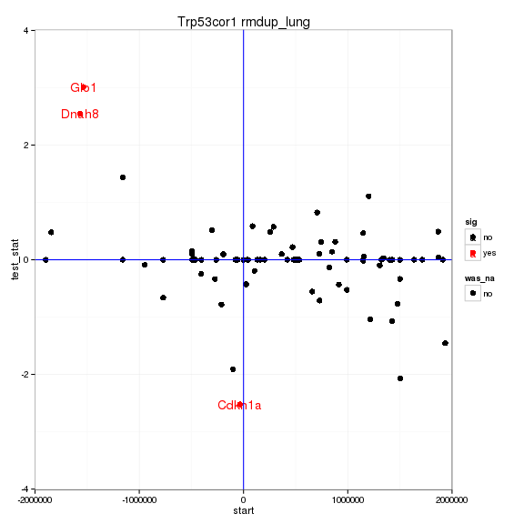

# Notes

## Samples used are:

|  | 11 |
| --- | --- |
| 1 | rmdup_lung_wt1 |
| 2 | rmdup_lung_wt2 |
| 3 | rmdup_lung_wt3 |
| 4 | rmdup_lung_ko1 |
| 5 | rmdup_lung_ko2 |
| 6 | rmdup_lung_ko3 |

## Replicates

|  | file | sample_name | replicate | rep_name | total_mass | norm_mass | internal_scale | external_scale |
| --- | --- | --- | --- | --- | --- | --- | --- | --- |
| 1 | /n/rinn_data1/users/agroff/seq/OtherMice/Diana/lincP21/quants/rmdup_lung_wt1/abundances.cxb | WT | 0 | WT_0 | 16225400.00 | 18312100.00 | 0.87 | 1.00 |
| 2 | /n/rinn_data1/users/agroff/seq/OtherMice/Diana/lincP21/quants/rmdup_lung_wt2/abundances.cxb | WT | 1 | WT_1 | 18606200.00 | 18312100.00 | 1.02 | 1.00 |
| 3 | /n/rinn_data1/users/agroff/seq/OtherMice/Diana/lincP21/quants/rmdup_lung_wt3/abundances.cxb | WT | 2 | WT_2 | 17545600.00 | 18312100.00 | 0.96 | 1.00 |
| 4 | /n/rinn_data1/users/agroff/seq/OtherMice/Diana/lincP21/quants/rmdup_lung_ko1/abundances.cxb | Trp53cor1 | 0 | Trp53cor1_0 | 17927400.00 | 18312100.00 | 0.99 | 1.00 |
| 5 | /n/rinn_data1/users/agroff/seq/OtherMice/Diana/lincP21/quants/rmdup_lung_ko2/abundances.cxb | Trp53cor1 | 1 | Trp53cor1_1 | 20691700.00 | 18312100.00 | 1.13 | 1.00 |
| 6 | /n/rinn_data1/users/agroff/seq/OtherMice/Diana/lincP21/quants/rmdup_lung_ko3/abundances.cxb | Trp53cor1 | 2 | Trp53cor1_2 | 19257700.00 | 18312100.00 | 1.06 | 1.00 |

## Run Info

[output not shown]